# The Sparks Foundation Internship

#### *Perform ‘Exploratory Data Analysis’ on dataset ‘SampleSuperstore’

1. Import
2. Exploratory Data Analysis
1. Correlation
2. Highest Selling By State
3. Highest Selling By City
4. Lowest Profit where Profit < 0 (Count)
5. Finding state with highest -ve Profit
6. Finding city with highest -ve Profit
7. Finding sub-category with highest -ve Profit
8. Finding Postal Code with highest -ve Profit
9. Texas
10. Ohio
11. Pennsylvania
3. Conclusions

## 1. Import Dataset

```python
# Essential package loading
import pandas as pd
import numpy as np
%matplotlib inline
%config InlineBackend.figure_format = 'retina'
import matplotlib.pyplot as plt
import seaborn as sns
sns.set_style('whitegrid')
plt.rcParams.update({'font.size': 18})
```

```python
# Data loading
df_store = pd.read_csv("SampleSuperstore.csv")
```

### `Showing few lines:`

```python
df_store.head(5)
```

|  | Ship Mode | Segment | Country | City | State | Postal Code | Region | Category | Sub-Category | Sales | Quantity | Discount | Profit |
| --- | --- | --- | --- | --- | --- | --- | --- | --- | --- | --- | --- | --- | --- |
| 0 | Second Class | Consumer | United States | Henderson | Kentucky | 42420 | South | Furniture | Bookcases | 261.9600 | 2 | 0.00 | 41.9136 |
| 1 | Second Class | Consumer | United States | Henderson | Kentucky | 42420 | South | Furniture | Chairs | 731.9400 | 3 | 0.00 | 219.5820 |
| 2 | Second Class | Corporate | United States | Los Angeles | California | 90036 | West | Office Supplies | Labels | 14.6200 | 2 | 0.00 | 6.8714 |
| 3 | Standard Class | Consumer | United States | Fort Lauderdale | Florida | 33311 | South | Furniture | Tables | 957.5775 | 5 | 0.45 | -383.0310 |
| 4 | Standard Class | Consumer | United States | Fort Lauderdale | Florida | 33311 | South | Office Supplies | Storage | 22.3680 | 2 | 0.20 | 2.5164 |

### `Checking for Duplicates`:

```python
sum(df_store.duplicated())
```

```
17
```

### `Rows and Columns (Shape):`

```python
df_store.shape
```

```
(9994, 13)
```

## 2. Exploratory Data Analysis

### Correlation

```python
df_store.corr()['Profit'].drop(['Profit'])
```

```
Postal Code   -0.029961
Sales          0.479064
Quantity       0.066253
Discount      -0.219487
Name: Profit, dtype: float64
```

This shows that profit could be having some correlation with sales figure

**`Heat Map`**

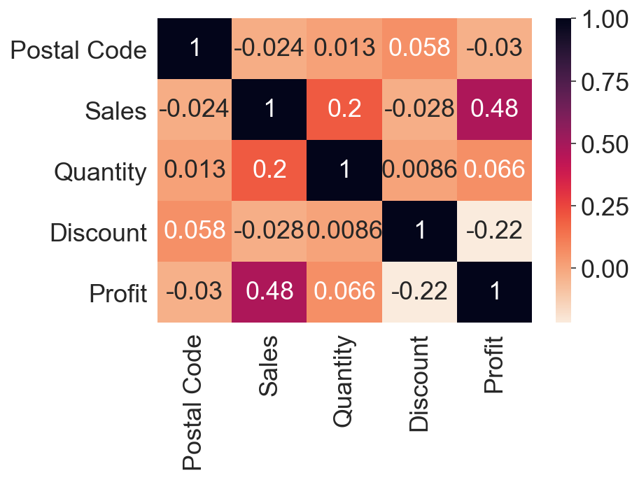

```python
sns.heatmap(df_store.corr(),cmap='rocket_r',annot=True)
```

## Highest Selling By State

```python
df_sales_state = df_store.groupby(['State']).sum().sort_values(by=['Sales'], ascending=False).head(20)
df_sales_state.reset_index(drop=False, inplace=True)
df_sales_state[['State', 'Sales', 'Profit']]
```

|  | State | Sales | Profit |
| --- | --- | --- | --- |
| 0 | California | 457687.6315 | 76381.3871 |
| 1 | New York | 310876.2710 | 74038.5486 |
| 2 | Texas | 170188.0458 | -25729.3563 |
| 3 | Washington | 138641.2700 | 33402.6517 |
| 4 | Pennsylvania | 116511.9140 | -15559.9603 |
| 5 | Florida | 89473.7080 | -3399.3017 |
| 6 | Illinois | 80166.1010 | -12607.8870 |
| 7 | Ohio | 78258.1360 | -16971.3766 |
| 8 | Michigan | 76269.6140 | 24463.1876 |
| 9 | Virginia | 70636.7200 | 18597.9504 |
| 10 | North Carolina | 55603.1640 | -7490.9122 |
| 11 | Indiana | 53555.3600 | 18382.9363 |
| 12 | Georgia | 49095.8400 | 16250.0433 |
| 13 | Kentucky | 36591.7500 | 11199.6966 |
| 14 | New Jersey | 35764.3120 | 9772.9138 |
| 15 | Arizona | 35282.0010 | -3427.9246 |
| 16 | Wisconsin | 32114.6100 | 8401.8004 |
| 17 | Colorado | 32108.1180 | -6527.8579 |
| 18 | Tennessee | 30661.8730 | -5341.6936 |
| 19 | Minnesota | 29863.1500 | 10823.1874 |

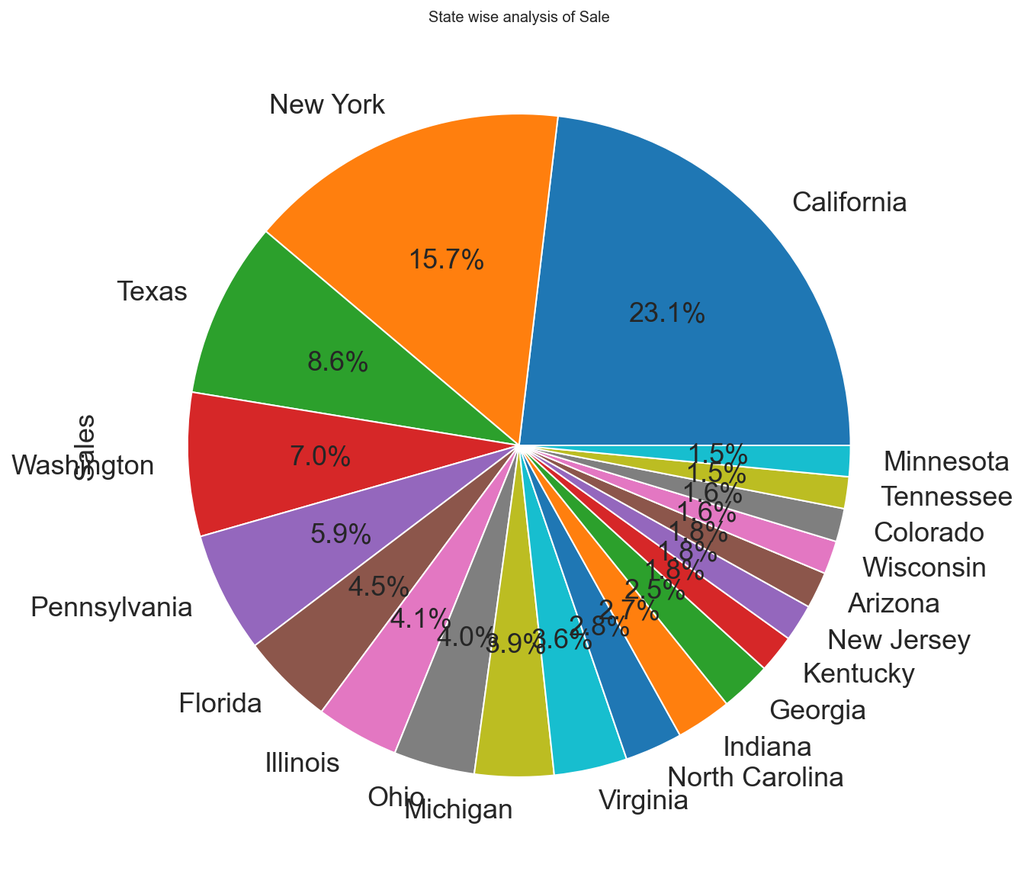

```python
df_sales_state0 = df_sales_state[['State', 'Sales']]
df_sales_state0.set_index('State', inplace=True)
df_sales_state0['Sales'].plot(kind='pie',
                        figsize = (10,10),
                        autopct='%1.1f%%',
                        shadow=False)
plt.title('State wise analysis of Sale',fontsize=10)
```

## Highest Selling By City

```python
df_sales_city = df_store.groupby(['City']).sum().sort_values(by=['Sales'], ascending=False).head(20)
df_sales_city.reset_index(drop=False, inplace=True)
df_sales_city[['City', 'Sales', 'Profit']]
```

|  | City | Sales | Profit |
| --- | --- | --- | --- |
| 0 | New York City | 256368.1610 | 62036.9837 |
| 1 | Los Angeles | 175851.3410 | 30440.7579 |
| 2 | Seattle | 119540.7420 | 29156.0967 |
| 3 | San Francisco | 112669.0920 | 17507.3854 |
| 4 | Philadelphia | 109077.0130 | -13837.7674 |
| 5 | Houston | 64504.7604 | -10153.5485 |
| 6 | Chicago | 48539.5410 | -6654.5688 |
| 7 | San Diego | 47521.0290 | 6377.1960 |
| 8 | Jacksonville | 44713.1830 | -2323.8350 |
| 9 | Springfield | 43054.3420 | 6200.6974 |
| 10 | Detroit | 42446.9440 | 13181.7908 |
| 11 | Columbus | 38706.2430 | 5897.1013 |
| 12 | Newark | 28576.1190 | 5793.7588 |
| 13 | Columbia | 25283.3240 | 5606.1167 |
| 14 | Lafayette | 25036.2000 | 10018.3876 |
| 15 | Jackson | 24963.8580 | 7581.6828 |
| 16 | San Antonio | 21843.5280 | -7299.0502 |
| 17 | Burlington | 21668.0820 | -3622.8772 |
| 18 | Arlington | 20214.5320 | 4169.6969 |
| 19 | Dallas | 20131.9322 | -2846.5257 |

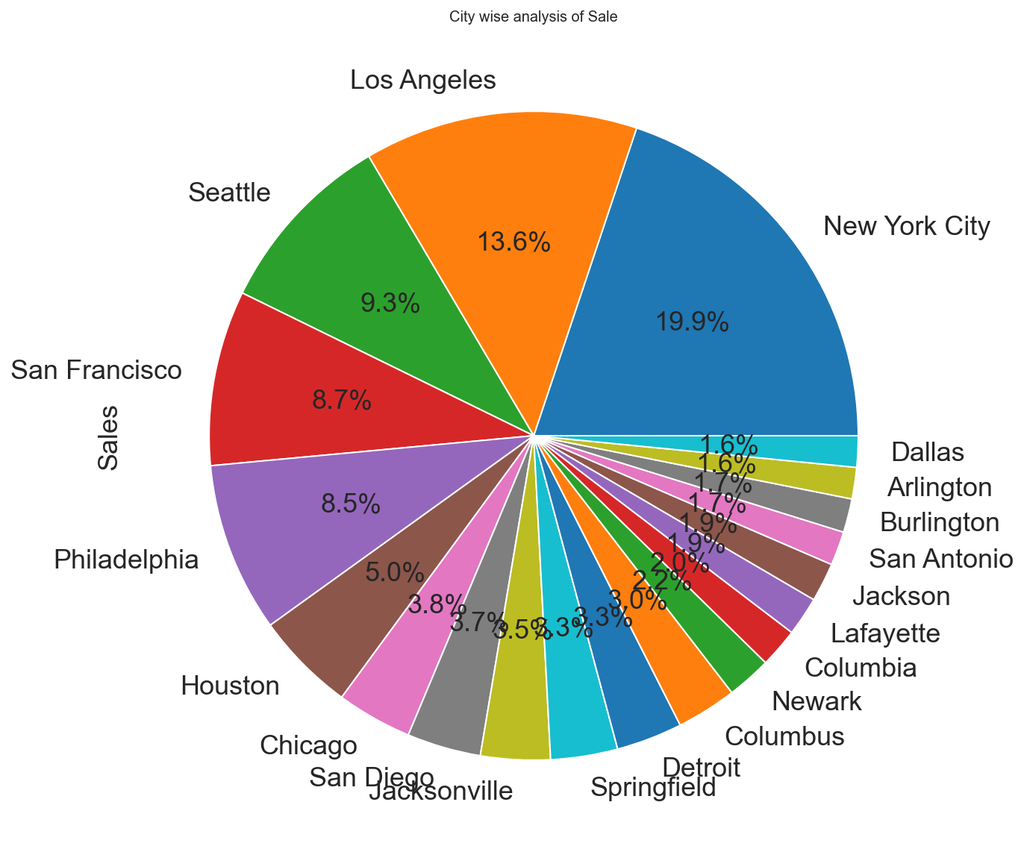

```python
df_sales_city0 = df_sales_city[['City', 'Sales']]
df_sales_city0.set_index('City', inplace=True)
df_sales_city0['Sales'].plot(kind='pie',
                        figsize = (10,10),
                        autopct='%1.1f%%',
                        shadow=False)
plt.title('City wise analysis of Sale',fontsize=10)
```

### Lowest Profit where Profit < 0 (Count)

```python
lowest = df_store.query('Profit < 0').sort_values(by=['Profit'])
lowest['Profit'].count()
```

```
1871
```

```python
#few lines:
lowest.head(5)
```

|  | Ship Mode | Segment | Country | City | State | Postal Code | Region | Category | Sub-Category | Sales | Quantity | Discount | Profit |
| --- | --- | --- | --- | --- | --- | --- | --- | --- | --- | --- | --- | --- | --- |
| 7772 | Standard Class | Consumer | United States | Lancaster | Ohio | 43130 | East | Technology | Machines | 4499.985 | 5 | 0.7 | -6599.9780 |
| 683 | Same Day | Corporate | United States | Burlington | North Carolina | 27217 | South | Technology | Machines | 7999.980 | 4 | 0.5 | -3839.9904 |
| 9774 | Standard Class | Consumer | United States | San Antonio | Texas | 78207 | Central | Office Supplies | Binders | 2177.584 | 8 | 0.8 | -3701.8928 |
| 3011 | Standard Class | Home Office | United States | Louisville | Colorado | 80027 | West | Technology | Machines | 2549.985 | 5 | 0.7 | -3399.9800 |
| 4991 | Standard Class | Corporate | United States | Chicago | Illinois | 60653 | Central | Office Supplies | Binders | 1889.990 | 5 | 0.8 | -2929.4845 |

## `Finding state with highest -ve Profit`

```python
df_state = df_store.groupby('State').sum().sort_values(by=['Profit']).head(20)
df_state.reset_index(drop=False, inplace=True)
df_state
```

|  | State | Postal Code | Sales | Quantity | Discount | Profit |
| --- | --- | --- | --- | --- | --- | --- |
| 0 | Texas | 75747693 | 170188.0458 | 3724 | 364.64 | -25729.3563 |
| 1 | Ohio | 20579836 | 78258.1360 | 1759 | 152.40 | -16971.3766 |
| 2 | Pennsylvania | 11190565 | 116511.9140 | 2153 | 192.90 | -15559.9603 |
| 3 | Illinois | 29873772 | 80166.1010 | 1845 | 191.90 | -12607.8870 |
| 4 | North Carolina | 6994384 | 55603.1640 | 983 | 70.60 | -7490.9122 |
| 5 | Colorado | 14613828 | 32108.1180 | 693 | 57.60 | -6527.8579 |
| 6 | Tennessee | 6890574 | 30661.8730 | 681 | 53.30 | -5341.6936 |
| 7 | Arizona | 19102126 | 35282.0010 | 862 | 68.00 | -3427.9246 |
| 8 | Florida | 12640225 | 89473.7080 | 1379 | 114.65 | -3399.3017 |
| 9 | Oregon | 12072125 | 17431.1500 | 499 | 35.80 | -1190.4705 |
| 10 | Wyoming | 82001 | 1603.1360 | 4 | 0.20 | 100.1960 |
| 11 | West Virginia | 104012 | 1209.8240 | 18 | 0.30 | 185.9216 |
| 12 | North Dakota | 406721 | 919.9100 | 30 | 0.00 | 230.1497 |
| 13 | South Dakota | 686730 | 1315.5600 | 42 | 0.00 | 394.8283 |
| 14 | Maine | 34725 | 1270.5300 | 35 | 0.00 | 454.4862 |
| 15 | Idaho | 1752709 | 4382.4860 | 64 | 1.80 | 826.7231 |
| 16 | Kansas | 1603798 | 2914.3100 | 74 | 0.00 | 836.4435 |
| 17 | District of Columbia | 200160 | 2865.0200 | 40 | 0.00 | 1059.5893 |
| 18 | New Mexico | 3241556 | 4783.5220 | 151 | 2.20 | 1157.1161 |
| 19 | Iowa | 1537707 | 4579.7600 | 112 | 0.00 | 1183.8119 |

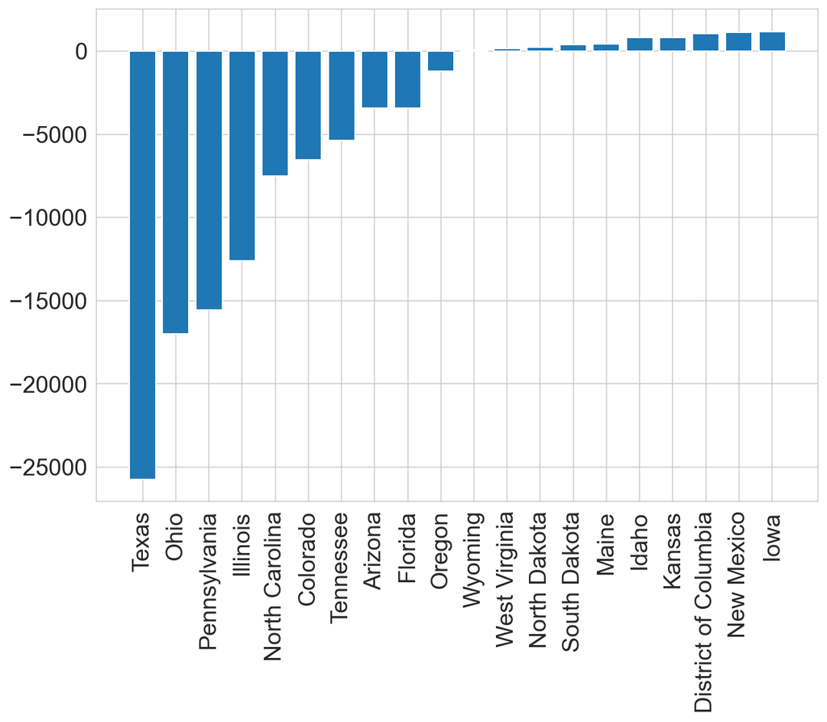

```python
#top 20 states having heighest -ve/+ve profit

State = df_state['State']
profit = df_state['Profit']

# Figure Size
fig = plt.figure(figsize =(10, 7))

# Horizontal Bar Plot
plt.bar(State, profit)
plt.xticks(State, rotation='vertical')

# Show Plot
plt.show()
```

```python
df_sales_state[['State', 'Sales', 'Profit']].query('Profit < 0')
```

|  | State | Sales | Profit |
| --- | --- | --- | --- |
| 2 | Texas | 170188.0458 | -25729.3563 |
| 4 | Pennsylvania | 116511.9140 | -15559.9603 |
| 5 | Florida | 89473.7080 | -3399.3017 |
| 6 | Illinois | 80166.1010 | -12607.8870 |
| 7 | Ohio | 78258.1360 | -16971.3766 |
| 10 | North Carolina | 55603.1640 | -7490.9122 |
| 15 | Arizona | 35282.0010 | -3427.9246 |
| 17 | Colorado | 32108.1180 | -6527.8579 |
| 18 | Tennessee | 30661.8730 | -5341.6936 |

Above Data shows that despite having larger number of sales Texas, Pennsylvania, Florida ans other States are losing money

## `Finding city with highest -ve Profit`

```python
df_store['City'].nunique()
```

```
531
```

```python
df_city = df_store.groupby('City').sum().sort_values(by=['Profit']).head(20)
df_city.reset_index(drop=False, inplace=True)
df_city
```

|  | City | Postal Code | Sales | Quantity | Discount | Profit |
| --- | --- | --- | --- | --- | --- | --- |
| 0 | Philadelphia | 10275302 | 109077.0130 | 1981 | 175.50 | -13837.7674 |
| 1 | Houston | 29052387 | 64504.7604 | 1466 | 143.14 | -10153.5485 |
| 2 | San Antonio | 4614213 | 21843.5280 | 247 | 22.60 | -7299.0502 |
| 3 | Lancaster | 1980720 | 9891.4640 | 171 | 14.50 | -7239.0684 |
| 4 | Chicago | 19037248 | 48539.5410 | 1132 | 120.50 | -6654.5688 |
| 5 | Burlington | 516678 | 21668.0820 | 105 | 3.40 | -3622.8772 |
| 6 | Dallas | 11802703 | 20131.9322 | 555 | 56.30 | -2846.5257 |
| 7 | Phoenix | 5356449 | 11000.2570 | 224 | 22.30 | -2790.8832 |
| 8 | Aurora | 4777612 | 11656.4780 | 258 | 24.00 | -2691.7386 |
| 9 | Jacksonville | 3843200 | 44713.1830 | 429 | 35.85 | -2323.8350 |
| 10 | Memphis | 1143270 | 5942.3410 | 116 | 8.40 | -1479.0400 |
| 11 | Louisville | 3247710 | 12345.8060 | 221 | 8.10 | -1430.3129 |
| 12 | Medina | 398304 | 2477.7220 | 38 | 3.90 | -1343.0446 |
| 13 | Round Rock | 550648 | 4854.0528 | 23 | 1.92 | -1183.4313 |
| 14 | Knoxville | 910032 | 3928.1660 | 81 | 6.20 | -1165.0755 |
| 15 | Miami | 1890806 | 8673.0745 | 215 | 18.65 | -1150.3704 |
| 16 | Rockford | 672177 | 3166.2280 | 64 | 5.60 | -1149.5078 |
| 17 | Clarksville | 259294 | 2217.7300 | 27 | 1.90 | -1055.3532 |
| 18 | Bethlehem | 90090 | 1689.6340 | 18 | 1.90 | -1003.0958 |
| 19 | Colorado Springs | 2022650 | 3694.0090 | 110 | 8.30 | -956.6841 |

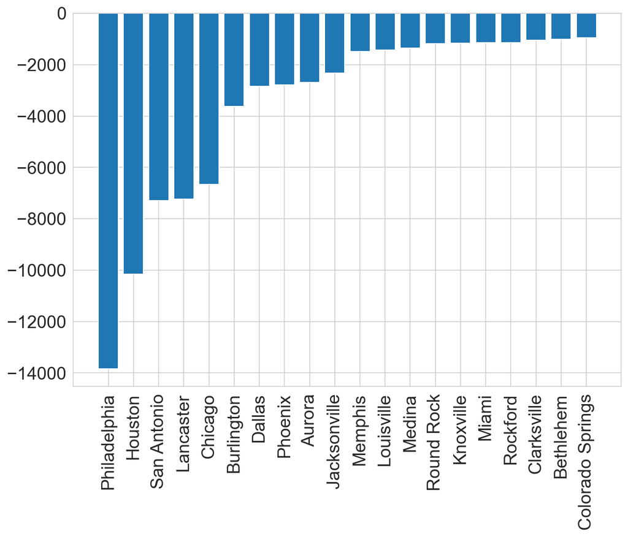

```python
#top 20 cities having heighest -ve profit

city = df_city['City']
sales = df_sales_city['Sales']
profit = df_city['Profit']

# Figure Size
fig = plt.figure(figsize =(10, 7))

# Horizontal Bar Plot
plt.bar(city, profit)
plt.xticks(city, rotation='vertical')

# Show Plot
plt.show()
```

```python
df_sales_city[['City', 'Sales', 'Profit']].query('Profit < 0')
```

|  | City | Sales | Profit |
| --- | --- | --- | --- |
| 4 | Philadelphia | 109077.0130 | -13837.7674 |
| 5 | Houston | 64504.7604 | -10153.5485 |
| 6 | Chicago | 48539.5410 | -6654.5688 |
| 8 | Jacksonville | 44713.1830 | -2323.8350 |
| 16 | San Antonio | 21843.5280 | -7299.0502 |
| 17 | Burlington | 21668.0820 | -3622.8772 |
| 19 | Dallas | 20131.9322 | -2846.5257 |

Above Data shows that despite having larger number of sales Philadelphia, Houston, Chicago and other Cities are losing money

## `Finding sub-category with highest -ve Profit`

```python
df_store.groupby(['Category', 'Sub-Category']).sum().sort_values(by=['Profit'])
```

| Category | Sub-Category | Postal Code | Sales | Quantity | Discount | Profit |
| --- | --- | --- | --- | --- | --- | --- |
| Furniture | Tables | 18607828 | 206965.5320 | 1241 | 83.35 | -17725.4811 |
|  | Bookcases | 12771539 | 114879.9963 | 868 | 48.14 | -3472.5560 |
| Office Supplies | Supplies | 10633558 | 46673.5380 | 647 | 14.60 | -1189.0995 |
|  | Fasteners | 12506063 | 3024.2800 | 914 | 17.80 | 949.5182 |
| Technology | Machines | 6364668 | 189238.6310 | 440 | 35.20 | 3384.7569 |
| Office Supplies | Labels | 19552985 | 12486.3120 | 1400 | 25.00 | 5546.2540 |
|  | Art | 43329658 | 27118.7920 | 3000 | 59.60 | 6527.7870 |
|  | Envelopes | 13325731 | 16476.4020 | 906 | 20.40 | 6964.1767 |
| Furniture | Furnishings | 51880430 | 91705.1640 | 3563 | 132.40 | 13059.1436 |
| Office Supplies | Appliances | 25250538 | 107532.1610 | 1729 | 77.60 | 18138.0054 |
|  | Storage | 46248720 | 223843.6080 | 3158 | 63.20 | 21278.8264 |
| Furniture | Chairs | 34936229 | 328449.1030 | 2356 | 105.00 | 26590.1663 |
| Office Supplies | Binders | 83626398 | 203412.7330 | 5974 | 567.00 | 30221.7633 |
|  | Paper | 76299221 | 78479.2060 | 5178 | 102.60 | 34053.5693 |
| Technology | Accessories | 44468434 | 167380.3180 | 2976 | 60.80 | 41936.6357 |
|  | Phones | 47897175 | 330007.0540 | 3289 | 137.40 | 44515.7306 |
|  | Copiers | 3873477 | 149528.0300 | 234 | 11.00 | 55617.8249 |

```python
df_category = df_store.groupby(['Sub-Category']).sum().sort_values(by=['Profit']).head(20)
df_category.reset_index(drop=False, inplace=True)
df_category
```

|  | Sub-Category | Postal Code | Sales | Quantity | Discount | Profit |
| --- | --- | --- | --- | --- | --- | --- |
| 0 | Tables | 18607828 | 206965.5320 | 1241 | 83.35 | -17725.4811 |
| 1 | Bookcases | 12771539 | 114879.9963 | 868 | 48.14 | -3472.5560 |
| 2 | Supplies | 10633558 | 46673.5380 | 647 | 14.60 | -1189.0995 |
| 3 | Fasteners | 12506063 | 3024.2800 | 914 | 17.80 | 949.5182 |
| 4 | Machines | 6364668 | 189238.6310 | 440 | 35.20 | 3384.7569 |
| 5 | Labels | 19552985 | 12486.3120 | 1400 | 25.00 | 5546.2540 |
| 6 | Art | 43329658 | 27118.7920 | 3000 | 59.60 | 6527.7870 |
| 7 | Envelopes | 13325731 | 16476.4020 | 906 | 20.40 | 6964.1767 |
| 8 | Furnishings | 51880430 | 91705.1640 | 3563 | 132.40 | 13059.1436 |
| 9 | Appliances | 25250538 | 107532.1610 | 1729 | 77.60 | 18138.0054 |
| 10 | Storage | 46248720 | 223843.6080 | 3158 | 63.20 | 21278.8264 |
| 11 | Chairs | 34936229 | 328449.1030 | 2356 | 105.00 | 26590.1663 |
| 12 | Binders | 83626398 | 203412.7330 | 5974 | 567.00 | 30221.7633 |
| 13 | Paper | 76299221 | 78479.2060 | 5178 | 102.60 | 34053.5693 |
| 14 | Accessories | 44468434 | 167380.3180 | 2976 | 60.80 | 41936.6357 |
| 15 | Phones | 47897175 | 330007.0540 | 3289 | 137.40 | 44515.7306 |
| 16 | Copiers | 3873477 | 149528.0300 | 234 | 11.00 | 55617.8249 |

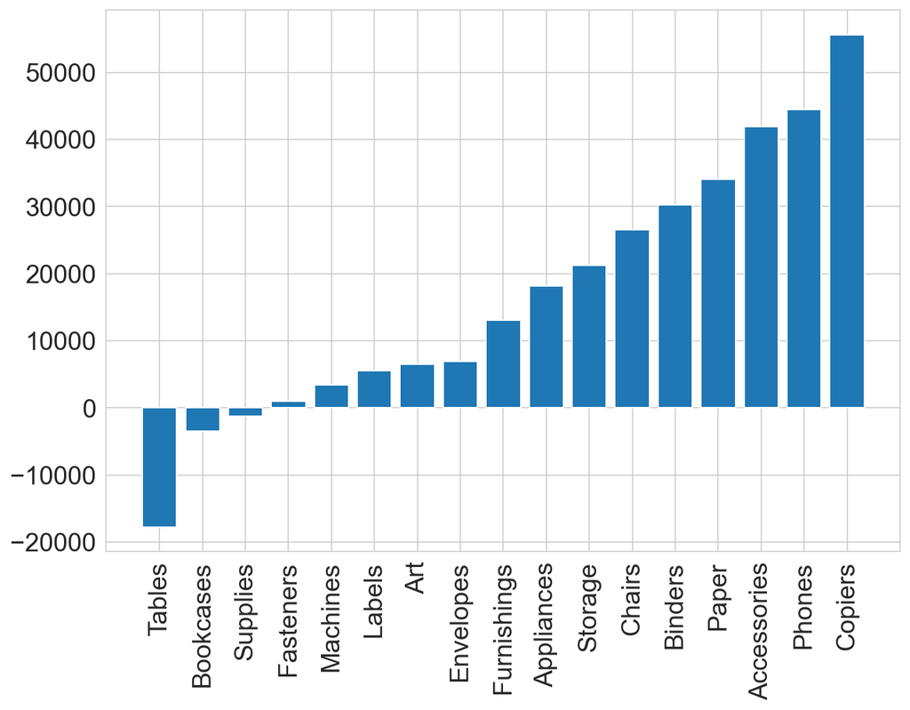

```python
#top 20 sub-categories having heighest -ve/+ve profit

sub_category = df_category['Sub-Category']
profit = df_category['Profit']

# Figure Size
fig = plt.figure(figsize =(10, 7))

# Horizontal Bar Plot
plt.bar(sub_category, profit)
plt.xticks(sub_category, rotation='vertical')

# Show Plot
plt.show()
```